# Proyecto 3. Avances 1. Eda y Clustering

Pablo Daniel Barillas Moreno, Carné No. 22193

Mathew Cordero Aquino, Carné No. 22982

Rafael Andres Chivalan

2025-03-14

## Enlace al Repositorio del proyecto 3 de minería de datos del Grupo #1

[Repositorio en GitHub](https://github.com/DanielBarillas/Proyecto-3_MineriaDeDatos_Grupo-1.git)

## 0. Descargar los conjuntos de datos.

Para este punto ya se descargo el .sav (formato SPSS) de año por año de la página [Instituto Nacional de Estadística - Guatemala](https://www.ine.gob.gt/vitales/), de nacimiento de bebes del país (Guatemala), para su posterior análisis.

Para este análisis se utilizaron los registros de nacimientos publicados por el Instituto Nacional de Estadística (INE) desde el año 2009 hasta 2022, en formato .sav (SPSS). En total, se procesaron 14 archivos, cada uno correspondiente a un año.

Cada archivo contiene datos individuales de nacimientos ocurridos en el país, con variables sobre el menor, la madre, el padre y condiciones del nacimiento.

## 1. Exploren los datos para encontrar preguntas interesantes y guías de investigación. Para esto:

**⚠️ Este bloque fue utilizado únicamente para generar el archivo limpio ‘datos_nacimientos_de_2009_a_2022.RData’.**

**No es necesario volver a ejecutarlo a menos que se modifiquen los datos fuente (.sav).**

```r
library(haven)
library(dplyr)
library(purrr)
library(stringr)

# Ruta donde están los .sav
ruta <- "Nacimientos"
archivos <- list.files(path = ruta, pattern = "\\.sav$", full.names = TRUE)

# Diccionario de equivalencias para unificar nombres
diccionario_nombres <- c(
  "Viapar"     = "ViaPar",
  "Pueblopp"   = "PuebloPP",
  "Pueblopm"   = "PuebloPM",
  "ciuomad"    = "Ciuomad",
  "ciuopad"    = "Ciuopad",
  "munnam"     = "Munpnam",
  "mupreg"     = "Mupreg",
  "muprep"     = "Muprep",
  "muprem"     = "Muprem",
  "mupnam"     = "Mupnam"
)

# Función para renombrar columnas según diccionario
renombrar_columnas <- function(df) {
  names(df) <- recode(names(df), !!!diccionario_nombres)
  return(df)
}

# Paso 1: Obtener todas las columnas posibles estandarizadas
nombres_globales <- archivos %>%
  map(~ {
    df <- read_sav(.x)
    names(df) <- recode(names(df), !!!diccionario_nombres)
    names(df)
  }) %>%
  flatten_chr() %>%
  unique()

# Paso 2: Leer, limpiar, completar y etiquetar año
leer_estandarizado <- function(archivo) {
  tryCatch({
    df <- read_sav(archivo)
    df <- renombrar_columnas(df)
    df <- df %>% mutate(across(everything(), as.character))

    # Agregar columnas faltantes como NA
    faltantes <- setdiff(nombres_globales, names(df))
    df[faltantes] <- NA
    df <- df[, nombres_globales]

    # Agregar columna del año
    df$archivo <- basename(archivo)
    df$anio <- stringr::str_extract(df$archivo, "\\d{4}")

    return(df)
  }, error = function(e) {
    message("❌ Error en ", archivo, ": ", e$message)
    return(NULL)
  })
}

# Unir todos los archivos estandarizados
datos_completos <- archivos %>%
  map(leer_estandarizado) %>%
  bind_rows()

# 🔄 Convertir variables clave a numéricas
datos_completos <- datos_completos %>%
  mutate(
    Edadp = as.numeric(Edadp),
    Libras = as.numeric(Libras),
    Onzas = as.numeric(Onzas)
  )

# Guardar el .RData final
save(datos_completos, file = "datos_nacimientos_de_2009_a_2022.RData")

cat("✅ Archivo listo: 'datos_nacimientos_limpio.RData'\n")
cat("📦 Observaciones:", nrow(datos_completos), " | Variables:", ncol(datos_completos), "\n")
```

```r
# Cargar el archivo
load("datos_nacimientos_de_2009_a_2022.RData")

# Verifica si el objeto se cargó correctamente
ls()  # Debería mostrar "datos_completos"
```

```
## [1] "datos_completos"
```

```r
# Verifica estructura
str(datos_completos)
```

```
## Classes 'tbl_df', 'tbl' and 'data.frame':    5195195 obs. of  55 variables:
##  $ Depreg  : chr  "1" "1" "1" "1" ...
##  $ Mupreg  : chr  "0101" "0101" "0101" "0101" ...
##  $ Mesreg  : chr  "8" "3" "2" "1" ...
##  $ Añoreg  : chr  "9" "10" "9" "10" ...
##  $ Depocu  : chr  "1" "1" "1" "1" ...
##  $ Mupocu  : chr  "0101" "0101" "0101" "0101" ...
##  $ Areag   : chr  "1" "1" "1" "1" ...
##  $ Libras  : num  5 5 5 6 6 4 8 7 7 7 ...
##  $ Onzas   : num  2 6 10 0 10 10 0 2 4 2 ...
##  $ Diaocu  : chr  "28" "2" "30" "7" ...
##  $ Mesocu  : chr  "6" "4" "1" "9" ...
##  $ Añoocu  : chr  "9" "9" "9" "9" ...
##  $ Sexo    : chr  "1" "1" "2" "2" ...
##  $ Tipar   : chr  "1" "1" "1" "1" ...
```

[output cut: 41 more lines]

```r
# Total de observaciones y variables
cat("🔎 Observaciones:", nrow(datos_completos), "\n")
```

```
## 🔎 Observaciones: 5195195
```

```r
cat("🔎 Variables:", ncol(datos_completos), "\n")
```

```
## 🔎 Variables: 55
```

```r
# Verifica cuántos registros hay por archivo original
table(datos_completos$archivo)
```

```
##
## nacimientos_de_2009.sav nacimientos_de_2010.sav nacimientos_de_2011.sav
##                  351628                  361906                  373692
## nacimientos_de_2012.sav nacimientos_de_2013.sav nacimientos_de_2014.sav
##                  388613                  387342                  386195
## nacimientos_de_2015.sav nacimientos_de_2016.sav nacimientos_de_2017.sav
##                  391425                  390382                  381664
## nacimientos_de_2018.sav nacimientos_de_2019.sav nacimientos_de_2020.sav
##                  383263                  366855                  341212
## nacimientos_de_2021.sav nacimientos_de_2022.sav
##                  345149                  345869
```

```r
# Cargar datos unificados
load("datos_nacimientos_de_2009_a_2022.RData")

library(dplyr)
library(tidyr)

# 1. Porcentaje de NA por columna
porcentaje_na <- datos_completos %>%
  summarise(across(everything(), ~mean(is.na(.))*100)) %>%
  pivot_longer(everything(), names_to = "variable", values_to = "porcentaje_na") %>%
  arrange(desc(porcentaje_na))

# 2. En qué años aparece cada variable (con datos no vacíos)
presencia_por_año <- datos_completos %>%
  group_by(archivo) %>%
  summarise(across(everything(), ~sum(!is.na(.)) > 0)) %>%
  pivot_longer(-archivo, names_to = "variable", values_to = "presente") %>%
  filter(presente == TRUE) %>%
  group_by(variable) %>%
  summarise(anios_con_dato = n()) %>%
  arrange(desc(anios_con_dato))

# 3. Unir resumen
resumen_variables <- porcentaje_na %>%
  left_join(presencia_por_año, by = "variable")

# 4. Ver tabla final
print(resumen_variables)
```

```
## # A tibble: 55 × 3
##    variable porcentaje_na anios_con_dato
##    <chr>            <dbl>          <int>
##  1 Gretnm            93.2              1
##  2 mupnap            93.0              1
##  3 Ciuopad           92.5              1
##  4 Munpnam           92.5              1
##  5 Ciuomad           85.1              2
##  6 Areag             79.1              3
##  7 grupetma          78.4              3
##  8 Gretnp            71.6              4
##  9 Naciop            64.1              5
## 10 Naciom            64.1              5
## # ℹ 45 more rows
```

### a. Describan el conjunto de datos: cuantas variables y observaciones hay y el tipo de cada una de las variables.

```r
# Cargar archivo
load("datos_nacimientos_de_2009_a_2022.RData")  # o datos_nacimientos_limpio.RData

library(dplyr)

# Obtener total de observaciones y variables
cat("📊 Total de observaciones:", nrow(datos_completos), "\n")
```

```
## 📊 Total de observaciones: 5195195
```

```r
cat("📊 Total de variables:", ncol(datos_completos), "\n\n")
```

```
## 📊 Total de variables: 55
```

```r
# Crear tabla con nombre, tipo y ejemplo por variable
resumen_variables <- tibble(
  variable = names(datos_completos),
  tipo = sapply(datos_completos, class),
  ejemplo = sapply(datos_completos, function(x) {
    first(na.omit(x))
  })
)

# Mostrar tabla resumen
print(resumen_variables)
```

```
## # A tibble: 55 × 3
##    variable tipo      ejemplo
##    <chr>    <chr>     <chr>
##  1 Depreg   character 1
##  2 Mupreg   character 0101
##  3 Mesreg   character 8
##  4 Añoreg   character 9
##  5 Depocu   character 1
##  6 Mupocu   character 0101
##  7 Areag    character 1
##  8 Libras   numeric   5
##  9 Onzas    numeric   2
## 10 Diaocu   character 28
## # ℹ 45 more rows
```

```r
# Importar librerías necesarias
library(haven)
library(dplyr)

# Ruta de la carpeta con los archivos .sav
ruta <- "Nacimientos"
archivos <- list.files(path = ruta, pattern = "\\.sav$", full.names = TRUE)

# Leer y resumir cada archivo
resumen <- lapply(archivos, function(archivo) {
  tryCatch({
    datos <- read_sav(archivo)
    list(
      archivo = basename(archivo),
      observaciones = nrow(datos),
      variables = ncol(datos),
      columnas = names(datos)
    )
  }, error = function(e) {
    list(
      archivo = basename(archivo),
      error = as.character(e)
    )
  })
})

# Mostrar resumen
print(resumen)
```

```
## [[1]]
## [[1]]$archivo
## [1] "nacimientos_de_2009.sav"
##
## [[1]]$observaciones
## [1] 351628
##
## [[1]]$variables
## [1] 37
##
## [[1]]$columnas
##  [1] "Depreg"   "mupreg"   "Mesreg"   "Añoreg"   "Depocu"   "Mupocu"
##  [7] "Areag"    "Libras"   "Onzas"    "Diaocu"   "Mesocu"   "Añoocu"
## [13] "Sexo"     "Tipar"    "Edadp"    "Deprep"   "muprep"   "Gretnp"
## [19] "Escivp"   "Depnap"   "Mupnap"   "Naciop"   "Ocupap"   "Edadm"
## [25] "Deprem"   "Muprem"   "Gretnm"   "Escivm"   "Depnam"   "Mupnam"
## [31] "Naciom"   "Ocupam"   "Asisrec"  "Sitioocu" "Tohite"   "Tohinm"
## [37] "Tohivi"
##
##
## [[2]]
## [[2]]$archivo
## [1] "nacimientos_de_2010.sav"
##
## [[2]]$observaciones
## [1] 361906
##
## [[2]]$variables
## [1] 39
##
## [[2]]$columnas
##  [1] "Depreg"   "mupreg"   "Mesreg"   "Añoreg"   "Depocu"   "Mupocu"
##  [7] "Areag"    "Libras"   "Onzas"    "Diaocu"   "Mesocu"   "Añoocu"
## [13] "Sexo"     "Tipar"    "Edadp"    "Deprep"   "muprep"   "Gretnp"
## [19] "Escivp"   "Depnap"   "mupnap"   "Naciop"   "Escolap"  "Ocupap"
## [25] "Edadm"    "Deprem"   "muprem"   "grupetma" "Escivm"   "Depnam"
## [31] "mupnam"   "Naciom"   "Escolam"  "Ocupam"   "Asisrec"  "Sitioocu"
## [37] "Tohite"   "Tohinm"   "Tohivi"
##
##
```

[output cut: 223 more lines]

```
##
## [[14]]$observaciones
## [1] 345869
##
## [[14]]$variables
## [1] 42
##
## [[14]]$columnas
##  [1] "Depreg"   "Mupreg"   "Mesreg"   "Añoreg"   "TipoIns"  "Depocu"
##  [7] "Mupocu"   "Libras"   "Onzas"    "Diaocu"   "Mesocu"   "Añoocu"
## [13] "Sexo"     "Tipar"    "Viapar"   "Edadp"    "Paisrep"  "Deprep"
## [19] "Muprep"   "Pueblopp" "Escivp"   "Paisnacp" "Depnap"   "Mupnap"
## [25] "Escolap"  "Ocupap"   "Edadm"    "Paisrem"  "Deprem"   "Muprem"
## [31] "Pueblopm" "Escivm"   "Paisnacm" "Depnam"   "Mupnam"   "Escolam"
## [37] "Ocupam"   "Asisrec"  "Sitioocu" "Tohite"   "Tohinm"   "Tohivi"
```

**Descripción General del Conjunto de Datos**

Para este análisis se utilizaron los registros de nacimientos publicados por el Instituto Nacional de Estadística (INE) desde el año **2009 hasta 2022**, en formato `.sav` (SPSS). En total, se procesaron **14 archivos**, cada uno correspondiente a un año.

Cada archivo contiene datos individuales de nacimientos ocurridos en el país, con variables sobre el menor, la madre, el padre y condiciones del nacimiento.

**Resumen por año:**

| Año | Observaciones | Variables |
| --- | --- | --- |
| 2009 | 351,628 | 37 |
| 2010 | 361,906 | 39 |
| 2011 | 373,692 | 39 |
| 2012 | 388,613 | 41 |
| 2013 | 387,342 | 41 |
| 2014 | 386,195 | 39 |
| 2015 | 391,425 | 42 |
| 2016 | 390,382 | 42 |
| 2017 | 381,664 | 42 |
| 2018 | 383,263 | 42 |
| 2019 | 366,855 | 42 |
| 2020 | 341,212 | 42 |
| 2021 | 345,149 | 42 |
| 2022 | 345,869 | 42 |

**Totales:**

- **Total de observaciones:** 5,195,195
- **Variables mínimas por año:** 37
- **Variables máximas por año:** 42

> Algunas variables tienen nombres distintos en ciertos años, pero representan la misma información. Se estandarizarán para el análisis posterior. Cuando una variable no está presente en todos los años, se conservará con valores `NA` según corresponda.

**Descripción del conjunto de datos**

El conjunto de datos corresponde a los registros de nacimientos recopilados por el Instituto Nacional de Estadística (INE) de Guatemala, desde el año **2009 hasta 2022**, en formato `.sav` (SPSS). Cada archivo representa un año y contiene información detallada sobre cada nacimiento ocurrido en el país.

**Contenido general:**

- **Años analizados:** 14 años (de 2009 a 2022)
- **Total de observaciones:** 5,195,195 nacimientos
- **Cantidad de variables por año:** entre **37 y 42**

**Variables y tipos**

A continuación se muestra una clasificación de los tipos de variables en los archivos:

[output not shown]

**Notas importantes:**

- Algunas variables tienen **nombres distintos entre años**, pero representan la misma información (ej. `"ViaPar"` vs `"Viapar"`).
- En el análisis se conservarán **todas las columnas**, y se colocará `NA` cuando alguna variable no esté presente en ciertos años.
- Se priorizará la estandarización de nombres antes de análisis agregados o gráficos.

**A continuación se tienen la descripción y clasificación de todas las variables:**

| **Variable** | **Descripción** |
| --- | --- |
| Depreg | Código del departamento donde se registró el nacimiento |
| Mupreg | Código del municipio donde se registró el nacimiento |
| Mesreg | Mes de registro del nacimiento |
| Añoreg | Año de registro del nacimiento |
| Depocu | Código del departamento donde ocurrió el nacimiento |
| Mupocu | Código del municipio donde ocurrió el nacimiento |
| Libras | Peso del bebé al nacer en libras |
| Onzas | Peso del bebé al nacer en onzas |
| Diaocu | Día en que ocurrió el nacimiento |
| Mesocu | Mes en que ocurrió el nacimiento |
| Añoocu | Año en que ocurrió el nacimiento |
| Sexo | Sexo del bebé (1 = Hombre, 2 = Mujer) |
| Tipar | Tipo de parto (1 = Vaginal, 2 = Cesárea, etc.) |
| Edadp | Edad del padre en años |
| Deprep | Departamento de residencia del padre |
| Muprep | Municipio de residencia del padre |
| Escivp | Estado civil del padre |
| Depnap | Departamento de nacimiento del padre |
| Mupnap | Municipio de nacimiento del padre |
| Naciop | Nacionalidad del padre (código) |
| Ocupap | Ocupación del padre (según clasificación nacional) |
| Edadm | Edad de la madre en años |
| Deprem | Departamento de residencia de la madre |
| Muprem | Municipio de residencia de la madre |
| Escivm | Estado civil de la madre |
| Depnam | Departamento de nacimiento de la madre |
| Mupnam | Municipio de nacimiento de la madre |
| Naciom | Nacionalidad de la madre (código) |
| Ocupam | Ocupación de la madre |
| Escolap | Nivel educativo alcanzado por el padre |
| Escolam | Nivel educativo alcanzado por la madre |
| Paisrep | País de residencia del padre |
| Paisrem | País de residencia de la madre |
| Paisnacp | País de nacimiento del padre |
| Paisnacm | País de nacimiento de la madre |
| Asisrec | Si hubo asistencia médica en el nacimiento |
| Sitioocu | Lugar donde ocurrió el nacimiento (hospital, casa, etc.) |
| TipoIns | Tipo de institución que atendió el parto (si aplica) |
| ViaPar / Viapar | Vía del parto (puede ser duplicado en nombre) |
| PuebloPP | Pertenencia étnica del padre (pueblo indígena, mestizo, etc.) |
| PuebloPM | Pertenencia étnica de la madre |
| Tohite | Total de hijos tenidos |
| Tohinm | Total de hijos nacidos muertos |
| Tohivi | Total de hijos vivos |
| grupetma | Clasificación del grupo étnico de la madre (código) |
| Gretnp | Grupo étnico del padre |
| Gretnm | Grupo étnico de la madre |
| Ciuopad | Ciudad de nacimiento del padre (algunos años) |
| Ciuomad | Ciudad de nacimiento de la madre (algunos años) |
| Munpnam | Municipio de nacimiento de la madre (alternativa a munnam) |
| archivo | Nombre del archivo del cual se extrajo el dato |
| anio | Año correspondiente al archivo (2009–2022) |

### b. Realicen un resumen de las variables numéricas e investiguen si siguen una distribución normal y, para las variables categóricas obtengan una tabla de frecuencia, documenten lo que vayan encontrando.

```r
# 🔧 Filtrar valores atípicos y mantener datos consistentes
datos_limpios <- datos_completos %>%
  mutate(
    Edadp  = as.numeric(Edadp),
    Edadm  = as.numeric(Edadm),
    Libras = as.numeric(Libras),
    Onzas  = as.numeric(Onzas),
    Tohite = as.numeric(Tohite),
    Tohinm = as.numeric(Tohinm),
    Tohivi = as.numeric(Tohivi)
  ) %>%
  filter(
    Edadp >= 10 & Edadp <= 90,
    Edadm >= 10 & Edadm <= 100,
    Libras >= 1 & Libras <= 10,
    Onzas >= 0 & Onzas <= 15,
    Tohite >= 0 & Tohite <= 20,
    Tohinm >= 0 & Tohinm <= 20,
    Tohivi >= 0 & Tohivi <= 20
  )

# Importar las librerías necesarias
library(dplyr)
library(ggplot2)

# Variables a analizar
vars_numericas <- c("Edadp", "Edadm", "Libras", "Onzas", "Tohite", "Tohinm", "Tohivi")
vars_categoricas <- c("Sexo", "Tipar", "Asisrec", "Sitioocu", "Escivp", "Escivm")

# 📊 Resumen estadístico
resumen_numerico <- datos_limpios %>%
  select(all_of(vars_numericas)) %>%
  summarise(across(everything(), list(
    media = ~mean(., na.rm = TRUE),
    mediana = ~median(., na.rm = TRUE),
    sd = ~sd(., na.rm = TRUE),
    min = ~min(., na.rm = TRUE),
    max = ~max(., na.rm = TRUE)
  ), .names = "{.col}_{.fn}"))

print(resumen_numerico)
```

```
## # A tibble: 1 × 35
##   Edadp_media Edadp_mediana Edadp_sd Edadp_min Edadp_max Edadm_media
##         <dbl>         <dbl>    <dbl>     <dbl>     <dbl>       <dbl>
## 1        29.5            28     8.03        12        90        25.9
## # ℹ 29 more variables: Edadm_mediana <dbl>, Edadm_sd <dbl>, Edadm_min <dbl>,
## #   Edadm_max <dbl>, Libras_media <dbl>, Libras_mediana <dbl>, Libras_sd <dbl>,
## #   Libras_min <dbl>, Libras_max <dbl>, Onzas_media <dbl>, Onzas_mediana <dbl>,
## #   Onzas_sd <dbl>, Onzas_min <dbl>, Onzas_max <dbl>, Tohite_media <dbl>,
## #   Tohite_mediana <dbl>, Tohite_sd <dbl>, Tohite_min <dbl>, Tohite_max <dbl>,
## #   Tohinm_media <dbl>, Tohinm_mediana <dbl>, Tohinm_sd <dbl>,
## #   Tohinm_min <dbl>, Tohinm_max <dbl>, Tohivi_media <dbl>, …
```

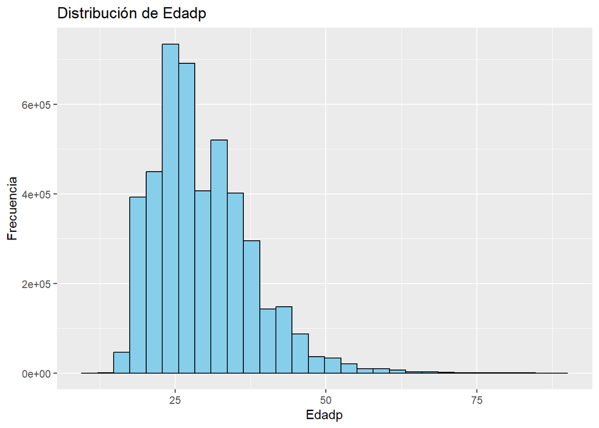

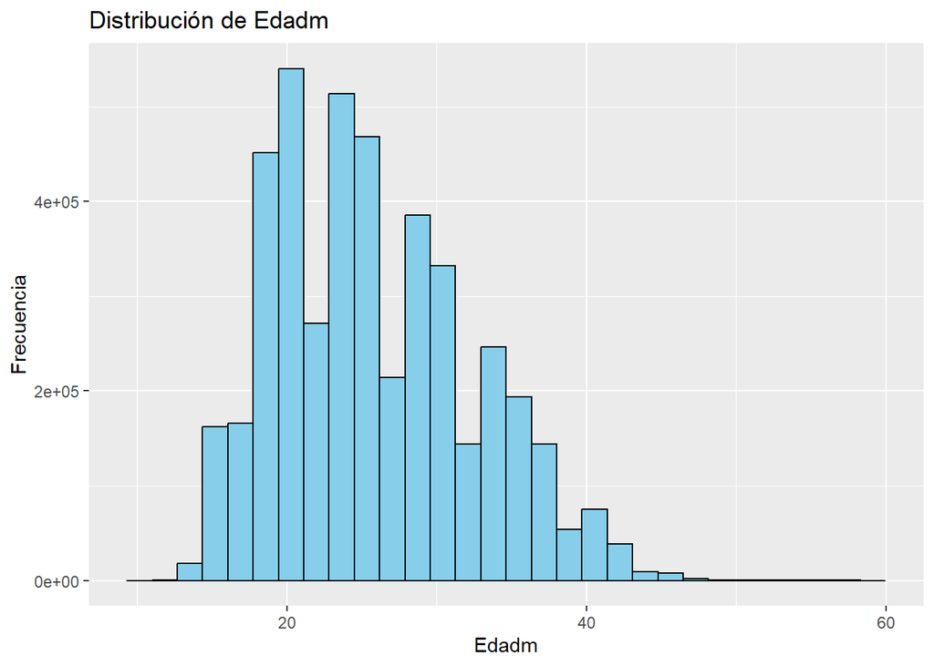

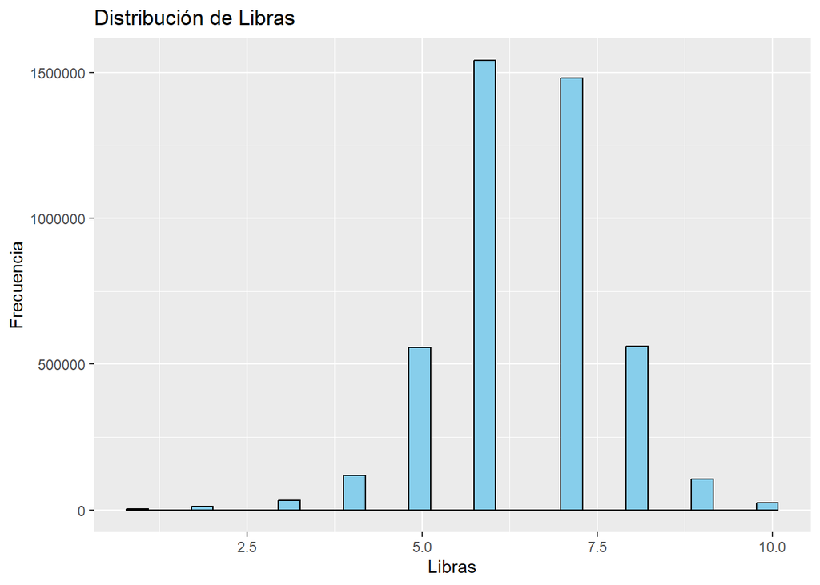

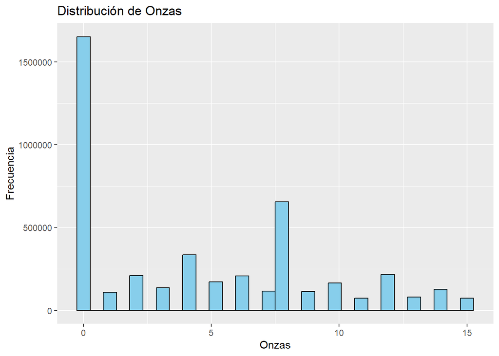

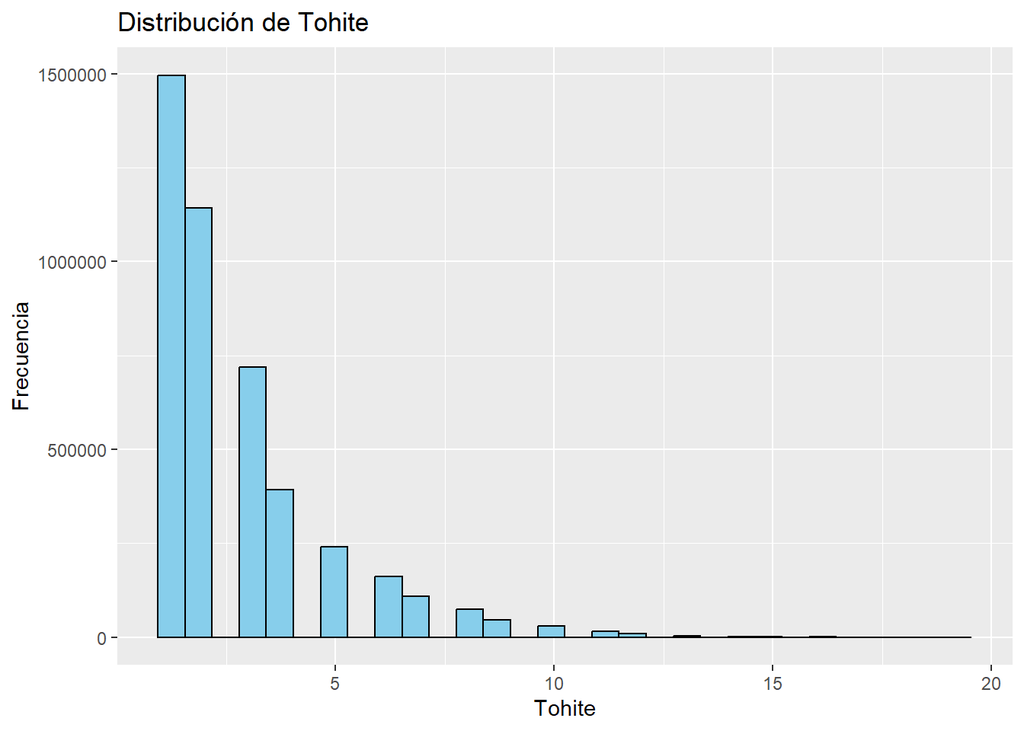

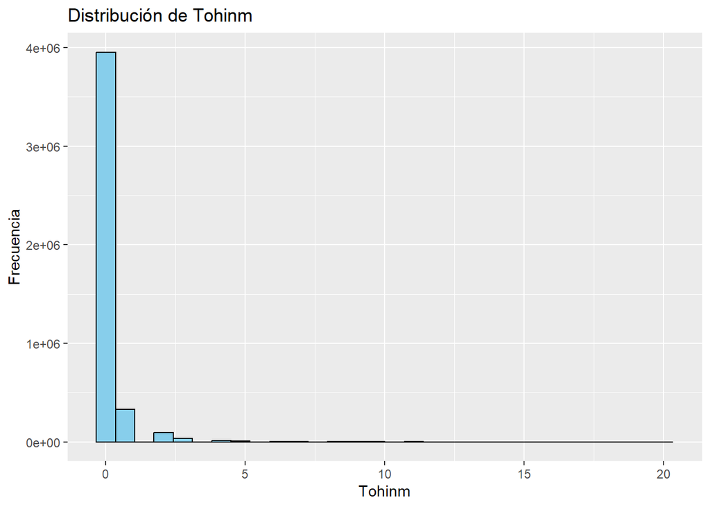

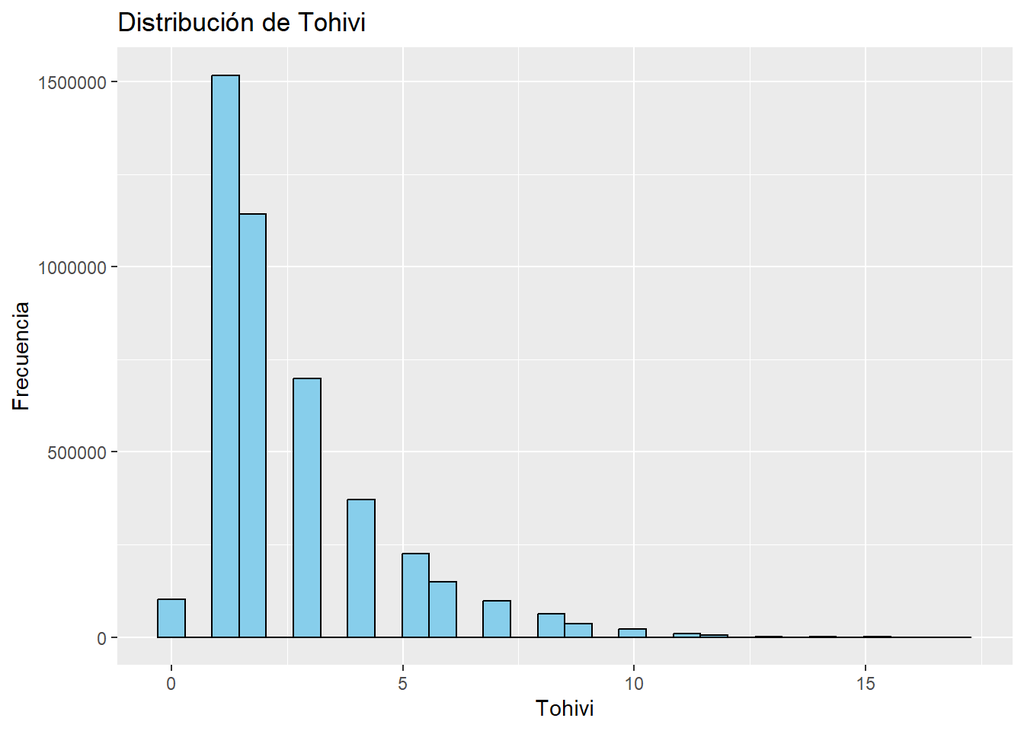

```r
# 📈 Histogramas (versión moderna de ggplot2 sin aes_string)
for (var in vars_numericas) {
  if (var %in% names(datos_limpios)) {
    print(
      ggplot(datos_limpios, aes(x = .data[[var]])) +
        geom_histogram(bins = 30, fill = "skyblue", color = "black") +
        labs(title = paste("Distribución de", var), x = var, y = "Frecuencia")
    )
  }
}
```

```r
# 📋 Tablas de frecuencia para variables categóricas
for (var in vars_categoricas) {
  if (var %in% names(datos_limpios)) {
    cat("\n📊 Frecuencia de:", var, "\n")
    print(table(datos_limpios[[var]], useNA = "ifany"))
  }
}
```

```
##
## 📊 Frecuencia de: Sexo
##
##       1       2
## 2254955 2184428
##
## 📊 Frecuencia de: Tipar
##
##       1       2       3       4
## 4385803   52701     791      88
##
## 📊 Frecuencia de: Asisrec
##
##       1       2       3       4       5       6       9
## 2818265  642548   61793  812238   55935   10042   38562
##
## 📊 Frecuencia de: Sitioocu
##
##       1       2       3       4       5       6       7       9
## 1689182  505277  349304  603829    2036 1240916     753   48086
##
## 📊 Frecuencia de: Escivp
##
##       1       2       3       9
## 2296789 2127728   13314    1552
##
## 📊 Frecuencia de: Escivm
##
##       1       2       3       9
## 2419613 2005703   12209    1858
```

### c. Crucen las variables que consideren sean las más importantes para hallar los elementos clave que permitan comprender lo que está causando el problema encontrado.

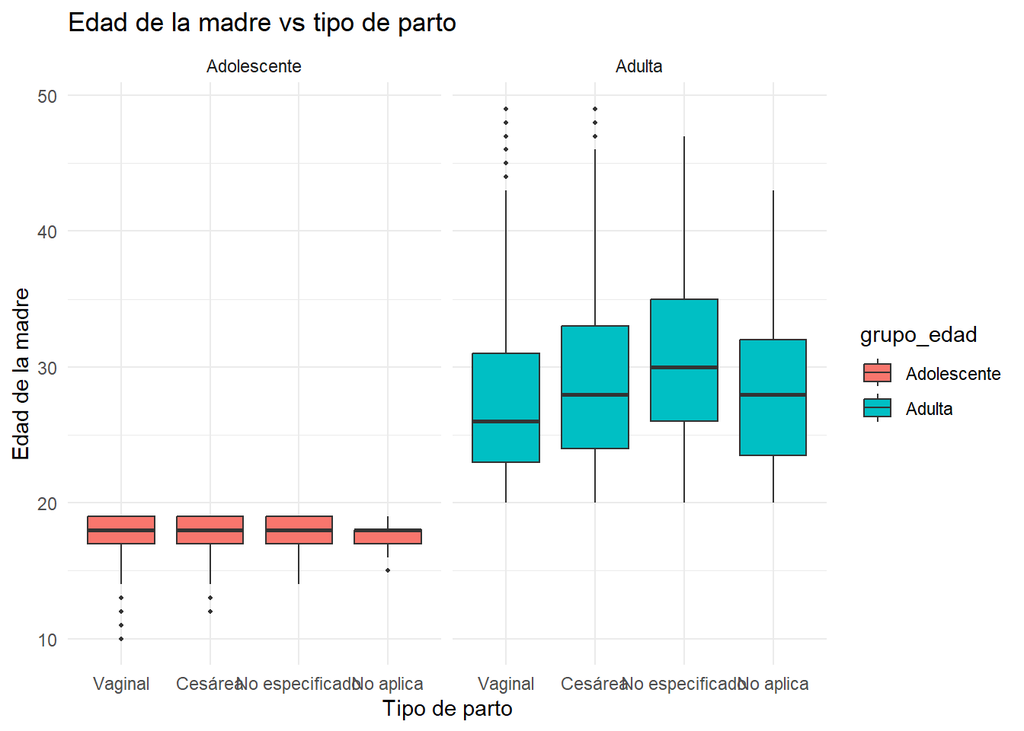

```r
# Librerías necesarias
library(dplyr)
library(ggplot2)
library(scales)

# Filtrar datos válidos
datos_validados <- datos_completos %>%
  mutate(
    Edadm = as.numeric(Edadm),
    Tipar = factor(Tipar, levels = c("1", "2", "3", "4"),
                   labels = c("Vaginal", "Cesárea", "No especificado", "No aplica")),
    Escolam = factor(Escolam, levels = c("1", "2", "3", "4", "5", "6"),
                     labels = c("Ninguna", "Primaria", "Secundaria", "Diversificado", "Superior", "No especificado")),
    Escivm = factor(Escivm, levels = c("1", "2", "3", "4", "5", "6"),
                    labels = c("Soltera", "Casada", "Unida", "Separada", "Divorciada", "Viuda")),
    Sitioocu = factor(Sitioocu, levels = c("1", "2", "3", "4", "5"),
                      labels = c("Hospital público", "Hospital privado", "Centro de salud", "Domicilio", "Otro")),
    Asisrec = factor(Asisrec, levels = c("1", "2", "3", "4"),
                     labels = c("Médico", "Enfermera", "Partera", "Otro")),
    grupo_edad = case_when(
      Edadm < 20 ~ "Adolescente",
      Edadm >= 20 & Edadm < 50 ~ "Adulta",
      TRUE ~ NA_character_
    )
  ) %>%
  filter(!is.na(grupo_edad))

# 🔹 1. Distribución de edad vs tipo de parto
ggplot(datos_validados, aes(x = Tipar, y = Edadm, fill = grupo_edad)) +
  geom_boxplot(outlier.size = 0.8) +
  labs(title = "Edad de la madre vs tipo de parto",
       x = "Tipo de parto", y = "Edad de la madre") +
  theme_minimal() +
  facet_wrap(~grupo_edad)
```

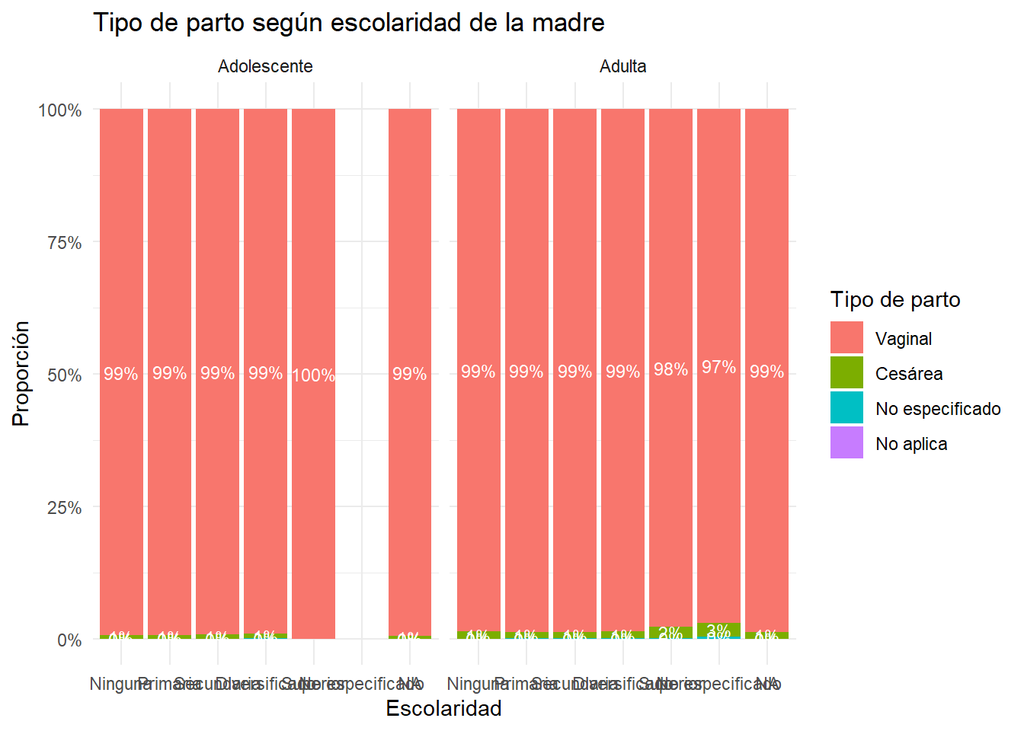

```r
# 🔹 2. Tipo de parto según escolaridad (con etiquetas)
df2 <- datos_validados %>%
  group_by(grupo_edad, Escolam, Tipar) %>%
  summarise(n = n(), .groups = "drop") %>%
  group_by(grupo_edad, Escolam) %>%
  mutate(prop = n / sum(n), etiqueta = percent(prop, accuracy = 1))

ggplot(df2, aes(x = Escolam, y = prop, fill = Tipar)) +
  geom_bar(stat = "identity", position = "fill") +
  geom_text(aes(label = etiqueta), position = position_fill(vjust = 0.5), size = 3, color = "white") +
  facet_wrap(~grupo_edad) +
  labs(title = "Tipo de parto según escolaridad de la madre",
       x = "Escolaridad", y = "Proporción", fill = "Tipo de parto") +
  scale_y_continuous(labels = percent_format()) +
  theme_minimal()
```

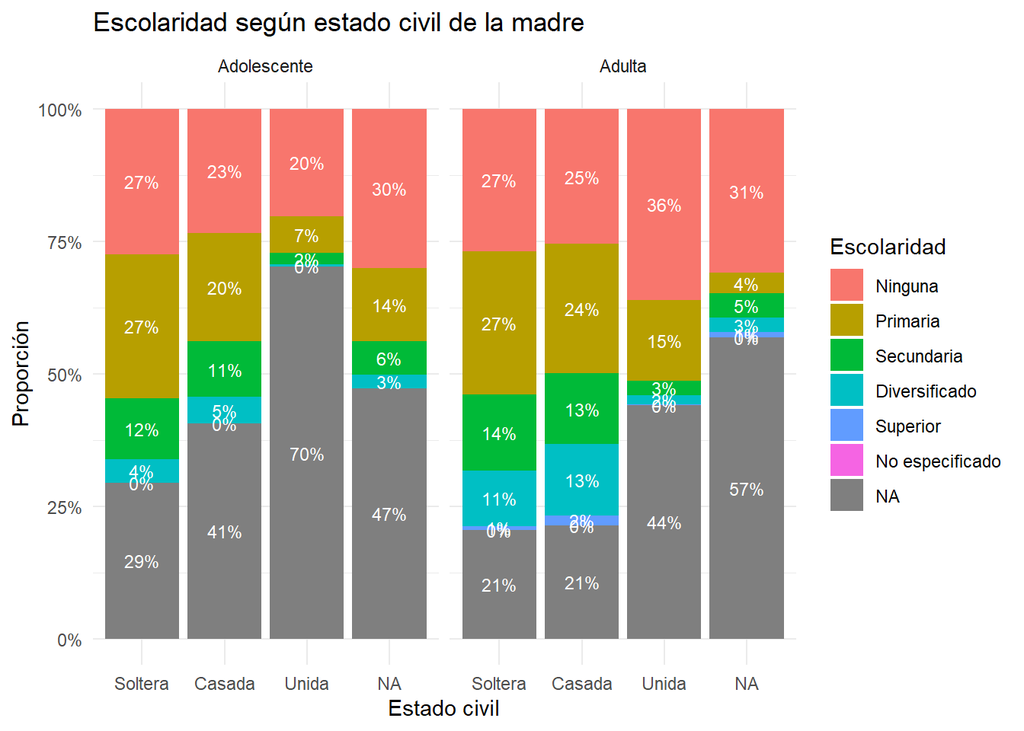

```r
# 🔹 3. Estado civil vs escolaridad (con etiquetas)
df3 <- datos_validados %>%
  group_by(grupo_edad, Escivm, Escolam) %>%
  summarise(n = n(), .groups = "drop") %>%
  group_by(grupo_edad, Escivm) %>%
  mutate(prop = n / sum(n), etiqueta = percent(prop, accuracy = 1))

ggplot(df3, aes(x = Escivm, y = prop, fill = Escolam)) +
  geom_bar(stat = "identity", position = "fill") +
  geom_text(aes(label = etiqueta), position = position_fill(vjust = 0.5), size = 3, color = "white") +
  facet_wrap(~grupo_edad) +
  labs(title = "Escolaridad según estado civil de la madre",
       x = "Estado civil", y = "Proporción", fill = "Escolaridad") +
  scale_y_continuous(labels = percent_format()) +
  theme_minimal()
```

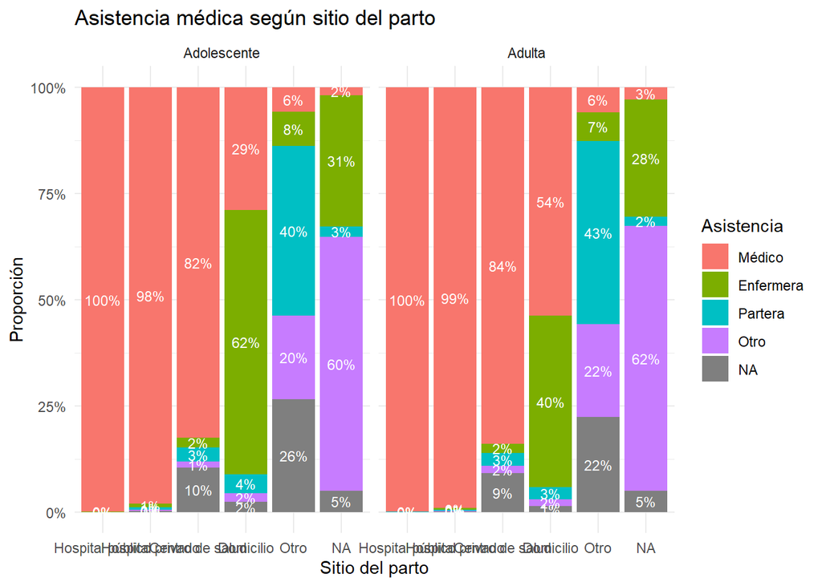

```r
# 🔹 4. Sitio del parto vs tipo de asistencia (con etiquetas)
df4 <- datos_validados %>%
  group_by(grupo_edad, Sitioocu, Asisrec) %>%
  summarise(n = n(), .groups = "drop") %>%
  group_by(grupo_edad, Sitioocu) %>%
  mutate(prop = n / sum(n), etiqueta = percent(prop, accuracy = 1))

ggplot(df4, aes(x = Sitioocu, y = prop, fill = Asisrec)) +
  geom_bar(stat = "identity", position = "fill") +
  geom_text(aes(label = etiqueta), position = position_fill(vjust = 0.5), size = 3, color = "white") +
  facet_wrap(~grupo_edad) +
  labs(title = "Asistencia médica según sitio del parto",
       x = "Sitio del parto", y = "Proporción", fill = "Asistencia") +
  scale_y_continuous(labels = percent_format()) +
  theme_minimal()
```

**1. Edad de la madre vs tipo de parto**

Este gráfico es un **diagrama de caja (boxplot)** que muestra la relación entre la **edad de la madre** y el **tipo de parto**, **segmentada por grupo etario**: *Adolescente* (menores de 20 años) y *Adulta* (20 años o más). Vamos a desglosarlo:

🟧 Eje horizontal (**Tipo de parto**): - **Vaginal** - **Cesárea** - **No especificado** - **No aplica**

🟦 Eje vertical (**Edad de la madre**): - Rango desde los **10 años** hasta más de **45 años**.

**Interpretación por grupo:**

🔴 **Adolescentes (rojo):**

- Sus edades están fuertemente concentradas entre **15 y 19 años**.
- Para **todos los tipos de parto**, la mediana está cerca de los **17-18 años**.
- Hay presencia de valores atípicos (*outliers*) menores a 15 años (algunas incluso de 10 a 12 años).
- Las cajas son muy pequeñas porque la edad varía poco en este grupo.

🟦 **Adultas (turquesa):**

- Tienen una mayor dispersión de edades (de 20 hasta 50+ años).
- La **mediana** de edad en partos vaginales es alrededor de **25 años**, mientras que en cesáreas y “no especificado” es más alta (27–30 años).
- Hay más presencia de **outliers hacia arriba** (madres mayores).

**Conclusiones que puedes sacar:**

1. **Las adolescentes tienen partos a una edad muy temprana**, sin importar el tipo de parto.
2. Las mujeres adultas presentan **más variedad en tipo de parto** y una **dispersión mayor en la edad**.
3. Las **cesáreas y partos no especificados** tienden a estar más asociados con mujeres adultas (mediana más alta).
4. El hecho de que las adolescentes tengan partos principalmente vaginales y con baja variación etaria **podría estar relacionado con falta de planificación familiar y acceso a servicios médicos diferenciados.**

**2. Tipo de parto según escolaridad de la madre**

Este gráfico **de barras apiladas y facetado por grupo de edad** muestra la **distribución proporcional del tipo de parto** (`Vaginal`, `Cesárea`, etc.) según la **escolaridad de la madre**, diferenciando entre madres **adolescentes** y **adultas**. a continuación se proporciona una explicación más detallada:

**¿Qué observamos?**

**Interpretación general:**

- **Eje X (horizontal):** Niveles de escolaridad de la madre (`Escolam`), desde “Ninguna” hasta “Superior”.
- **Eje Y (vertical):** Proporción de partos por cada tipo, expresada como porcentaje del total de partos dentro de cada categoría de escolaridad.
- **Colores:**
  - 🔴 Rojo: **Parto Vaginal**
  - 🟢 Verde: **Parto Cesárea**
  - 🔵 Azul: **No especificado**
  - 🟣 Morado: **No aplica** (aunque estos son casi invisibles o inexistentes en este gráfico)

**Hallazgos importantes:**

**Madres adolescentes:**

- El **99%–100%** de los partos son vaginales sin importar el nivel de escolaridad.
- Las cesáreas son **muy poco frecuentes** (solo 1%).
- Esto puede deberse a:
  - Menor acceso a servicios especializados.
  - Menor probabilidad de embarazos planificados.
  - Contextos más rurales o vulnerables.

**Madres adultas:**

- También predominan los partos vaginales (97%–99%), pero:
  - Hay una **ligera tendencia al aumento de cesáreas** con mayor escolaridad:
    - Por ejemplo, en nivel **superior**, 2% de cesáreas.
    - En “No especificado”, sube al 3%.
  - Esto podría reflejar:
    - Mayor planificación.
    - Mayor acceso a servicios médicos y partos programados.
    - Preferencia médica/personal por cesáreas en algunos contextos.

**Conclusión del gráfico:**

- **El tipo de parto está fuertemente dominado por partos vaginales**, especialmente entre las madres adolescentes.
- Las **madres adultas con mayor nivel educativo** presentan una leve mayor proporción de partos por cesárea.
- Este patrón **sugiere diferencias en el acceso a servicios de salud o en las decisiones clínicas según edad y escolaridad**.

**3. Escolaridad según estado civil de la madre**

Este gráfico muestra la **relación entre el estado civil y la escolaridad de la madre**, diferenciando entre madres **adolescentes** y **adultas**, con proporciones expresadas en porcentajes.

**Detalles del gráfico:**

- **Eje X (horizontal):** Estado civil de la madre (`Escivm`): Soltera, Casada, Unida, NA.
- **Eje Y (vertical):** Proporción de cada nivel de escolaridad.
- **Colores:** Representan los distintos niveles educativos (`Escolam`) desde “Ninguna” hasta “Superior”, y se incluye el grupo “NA” (dato faltante).
- **Facetado:** Dos paneles:
  - Izquierda: madres **adolescentes**
  - Derecha: madres **adultas**
- **Texto sobre cada barra:** porcentaje de cada grupo educativo dentro de cada categoría de estado civil.

**Madres adolescentes:**

**Conclusión:** Las madres adolescentes tienden a tener **niveles educativos bajos** (ninguno o primaria), con muy pocos casos de escolaridad media o superior.

**Madres adultas:**

- Mayor diversidad educativa:
  - Aunque todavía predominan los niveles bajos (Ninguna y Primaria con 27%+), se observa mayor presencia de **secundaria (13–14%)** y **diversificado (11–13%)**.
  - Algunas casadas tienen hasta 2% con **educación superior**.
- Las mujeres unidas y solteras tienen escolaridades más bajas comparadas con las casadas.

**Conclusión:** Las madres adultas presentan **mejor perfil educativo**, especialmente en el grupo casado.

**Reflexión clave:**

- Existe una **relación entre estado civil y escolaridad**: las madres casadas (tanto adolescentes como adultas) tienden a tener **más educación**.
- Las madres adolescentes **unidas o con datos faltantes** tienen niveles de escolaridad extremadamente bajos o desconocidos.

**4. Asistencia médica según sitio del parto**

Este gráfico muestra la **relación entre el sitio del parto y el tipo de asistencia médica recibida**, desagregada por grupo etario de la madre (adolescente vs adulta), y expresada en **proporciones porcentuales**.

**Ejes y elementos clave:**

- **Eje X:** Sitio del parto (`Sitioocu`): Hospital público, Hospital privado, Centro de salud, Domicilio, Otro, NA.
- **Eje Y:** Proporción de cada tipo de asistencia médica (`Asisrec`): Médico, Enfermera, Partera, Otro.
- **Colores:** Representan el tipo de asistencia médica.
- **Facetado:** Se comparan **madres adolescentes** y **madres adultas**.
- **Etiquetas:** Indican el **porcentaje exacto** que representa cada grupo dentro del total por barra.

**Madres adolescentes:**

- **Hospital público:** 100% con asistencia médica profesional (100% médico).
- **Hospital privado:** 98% médico, 1% enfermera.
- **Centro de salud:** 82% médico, pero hay mayor diversidad (2% enfermera, 3% partera, etc.).
- **Domicilio:** 62% asistidas por **enfermeras**, 29% por médico, 4% por partera.
- **Otros sitios:** Mayor fragmentación, con 40% partera, 20% otro, y 26% NA (no especificado).
- **NA (sitio desconocido):** 60% asistencia tipo “Otro”, 31% enfermera.

**Conclusión:** Las madres adolescentes que no dan a luz en hospitales tienen mayor probabilidad de ser atendidas por **personal no médico** o incluso parteras.

**Madres adultas:**

- **Hospital público:** 100% médico.
- **Hospital privado:** 99% médico.
- **Centro de salud:** 84% médico, pero aparece algo más de asistencia por parteras y enfermeras.
- **Domicilio:** 54% médico, 40% **enfermera**, 3% partera.
- **Otros sitios y NA:** distribución similar a adolescentes, pero con más casos asistidos por **parteras (43%)** y “Otro”.

**Conclusión:** Aunque las madres adultas también recurren a lugares no institucionales, su proporción de **asistencia médica es mayor** que en las adolescentes.

**Reflexión general:**

- **Los hospitales (públicos y privados)** garantizan asistencia médica profesional.
- **Los partos en domicilio o sitios alternativos** se asocian con mayor riesgo de **no recibir atención médica profesional**, especialmente en adolescentes.
- Esto puede estar relacionado con factores como **baja escolaridad, falta de acceso a servicios o decisiones familiares**.

## d. Realicen gráficos exploratorios que les dé ideas del estado de los datos.

Para hacer este analisis debemos de profundizar sobre los datos, Por ello vamos a utilizar algunas graficos que representen lo que estamos buscando

Lo primero es responder a las preguntas por ejemplo

¿El sexo del bebé influye en el peso al nacer?

Para ello realizamos el siguiente grafico

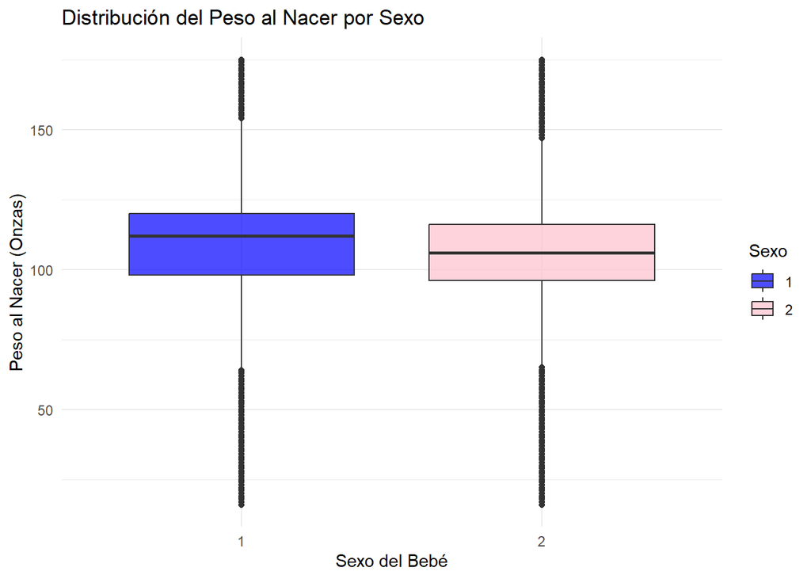

```r
library(haven)
library(dplyr)
library(ggplot2)

ruta <- "./datos_nacimientos_de_2009_a_2022.RData"

# Cargar el archivo RData
load(ruta)


# Crear una nueva variable con el peso total en onzas sin modificar Libras y Onzas originales
datos_limpios <- datos_completos %>%
  mutate(
    Edadp  = as.numeric(Edadp),
    Edadm  = as.numeric(Edadm),
    Libras = as.numeric(Libras),
    Onzas  = as.numeric(Onzas),
    Tohite = as.numeric(Tohite),
    Tohinm = as.numeric(Tohinm),
    Tohivi = as.numeric(Tohivi)
  ) %>%
  filter(
    Edadp >= 10 & Edadp <= 90,
    Edadm >= 10 & Edadm <= 100,
    Libras >= 1 & Libras <= 10,
    Onzas >= 0 & Onzas <= 15,
    Tohite >= 0 & Tohite <= 20,
    Tohinm >= 0 & Tohinm <= 20,
    Tohivi >= 0 & Tohivi <= 20
  )



datos_cambiados <- datos_limpios %>%
  mutate(Peso_Onzas = (Libras * 16) + Onzas)

# 📊 Gráfico de caja para comparar peso por sexo
ggplot(datos_cambiados, aes(x = Sexo, y = Peso_Onzas, fill = Sexo)) +
  geom_boxplot(alpha = 0.7) +
  labs(title = "Distribución del Peso al Nacer por Sexo",
       x = "Sexo del Bebé",
       y = "Peso al Nacer (Onzas)") +
  scale_fill_manual(values = c("blue", "pink")) +  # Colores típicos
  theme_minimal()
```

### Analisis del grafico

Podemos ver que realmente no afecta en nada el genero en la diferencia de pesos, si se puede ver que solo hay una ligera diferencia de pesos por las mujeres pesando menos pero no es mucho. Asi que puede ser por otros motivos

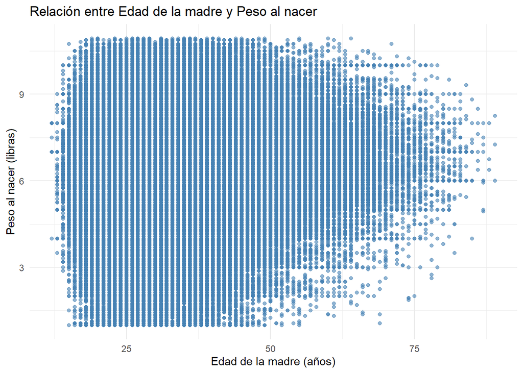

```
##              used   (Mb) gc trigger    (Mb)   max used    (Mb)
## Ncells    1192815   63.8    2000905   106.9    2000905   106.9
## Vcells 1077791318 8222.9 1850332272 14117.0 1541417821 11760.1
```

```r
library(haven)
library(dplyr)
library(ggplot2)
ruta <- "./datos_nacimientos_de_2009_a_2022.RData"

# Cargar el archivo RData
load(ruta)


# Crear una nueva variable con el peso total en onzas sin modificar Libras y Onzas originales
datos_limpios <- datos_completos %>%
  mutate(
    Edadp  = as.numeric(Edadp),
    Edadm  = as.numeric(Edadm),
    Libras = as.numeric(Libras),
    Onzas  = as.numeric(Onzas),
    Tohite = as.numeric(Tohite),
    Tohinm = as.numeric(Tohinm),
    Tohivi = as.numeric(Tohivi)
  ) %>%
  filter(
    Edadp >= 10 & Edadp <= 90,
    Edadm >= 10 & Edadm <= 100,
    Libras >= 1 & Libras <= 10,
    Onzas >= 0 & Onzas <= 15,
    Tohite >= 0 & Tohite <= 20,
    Tohinm >= 0 & Tohinm <= 20,
    Tohivi >= 0 & Tohivi <= 20
  )



datos_cambiados <- datos_limpios %>%
  mutate(Peso_Onzas = (Libras * 16) + Onzas)
# Etiquetas para tipo de parto
etiquetas_tipar <- c("1" = "Vaginal", "2" = "Cesárea", "3" = "No especificado", "4" = "No aplica")

# Variables que interesan
vars_numericas <- c("Edadp", "Libras", "Onzas")
vars_categoricas <- c("Sexo", "Escivp", "Escolap", "Asisrec", "Sitioocu")

tryCatch({
  # Convertir manualmente Tipar con etiquetas
  if ("Tipar" %in% names(datos_limpios)) {
    datos_limpios$Tipar <- as.character(datos_limpios$Tipar)
    datos_limpios$Tipar <- recode(datos_limpios$Tipar, !!!etiquetas_tipar)
    datos_limpios$Tipar <- factor(datos_limpios$Tipar)
  }

  # Convertir variables numéricas
  datos_limpios <- datos_limpios %>%
    mutate(
      Edadp = suppressWarnings(as.numeric(as.character(Edadp))),
      Libras = suppressWarnings(as.numeric(as.character(Libras))),
      Onzas = suppressWarnings(as.numeric(as.character(Onzas))),
      peso_total = Libras + (Onzas / 16)  # Calcular peso total en libras
    )

  # Convertir categóricas a factor si existen
  for (var in vars_categoricas) {
    if (var %in% names(datos_limpios)) {
      datos_limpios[[var]] <- as.factor(as.character(datos_limpios[[var]]))
    }
  }

  # Filtrar valores válidos
  datos_limpios <- datos_limpios %>%
    filter(Edadp < 90, Libras <= 10, Onzas <= 15)

  # 📊 Peso vs Edad de la madre
  if ("Edadp" %in% names(datos_limpios) && "peso_total" %in% names(datos_limpios)) {
    print(ggplot(datos_limpios, aes(x = Edadp, y = peso_total)) +
            geom_point(color = "steelblue", alpha = 0.6) +
            labs(title = "Relación entre Edad de la madre y Peso al nacer",
                 x = "Edad de la madre (años)", y = "Peso al nacer (libras)") +
            theme_minimal())
  }

  gc()

}, error = function(e) {
  message("❌ Error: ", e$message)
})
```